# Praca zaliczeniowa na przedmiot Modelowanie ryzyka kredytowego oraz budowy kart scoringowych w R

```
##      [,1]
## [1,]  0.7
## [2,]  1.9
## [3,]  3.1
```

```
## [1] 0.7 1.9
```

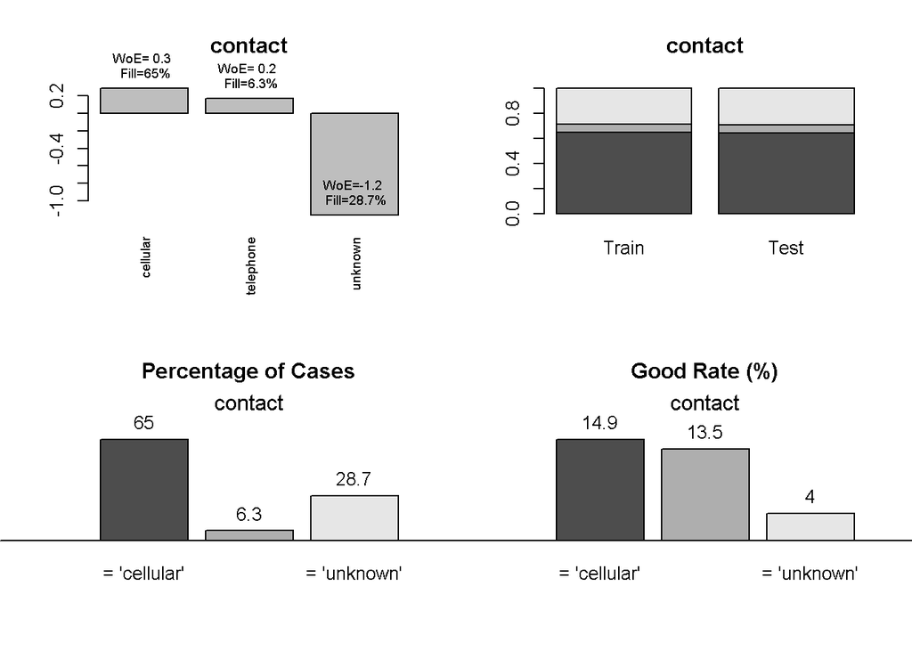

```
## Information Value 0.87
```

```
##      [,1]
## [1,]  0.7
## [2,]  1.9
## [3,]  3.1
```

```
## [1] 0.7 1.9
```

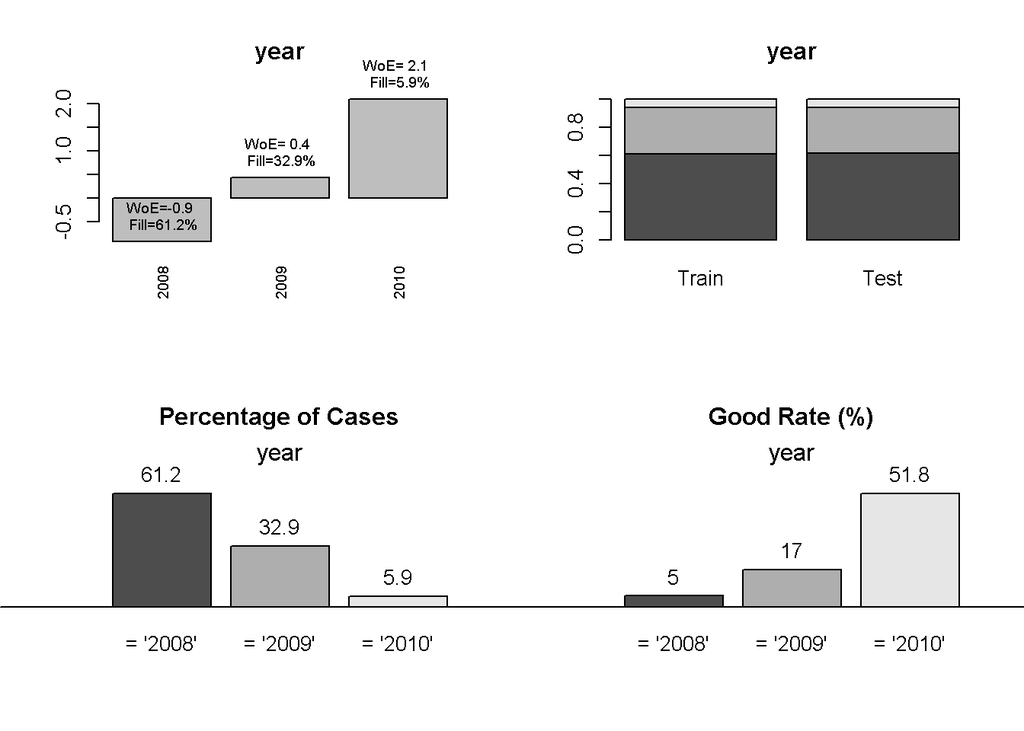

```
## Information Value 0.01
```

```
##      [,1]
## [1,]  0.7
## [2,]  1.9
## [3,]  3.1
## [4,]  4.3
## [5,]  5.5
## [6,]  6.7
```

```
## [1] 0.7 1.9
```

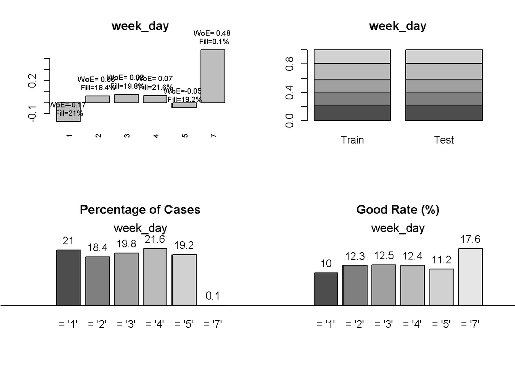

```
## Information Value 0.55
```

```
##      [,1]
## [1,]  0.7
## [2,]  1.9
## [3,]  3.1
## [4,]  4.3
```

```
## [1] 0.7 1.9
```

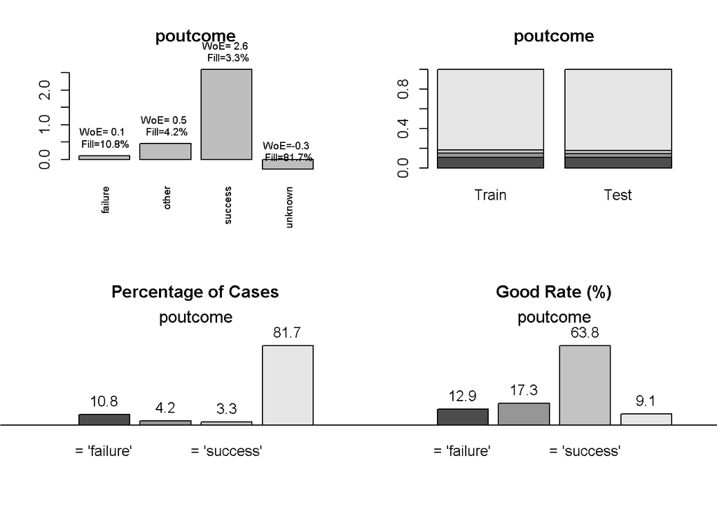

```
## Information Value 0.21
```

```
##      [,1]
## [1,]  0.7
## [2,]  1.9
## [3,]  3.1
## [4,]  4.3
## [5,]  5.5
## [6,]  6.7
```

```
## [1] 0.7 1.9
```

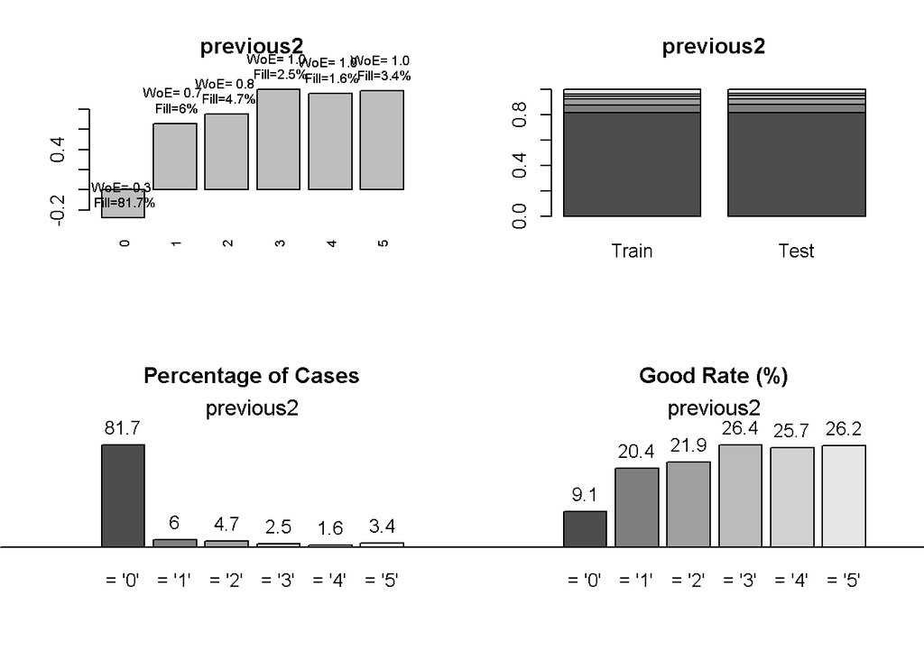

```
## Information Value 0.21
```

```
##      [,1]
## [1,]  0.7
## [2,]  1.9
```

```
## [1] 0.7 1.9
```

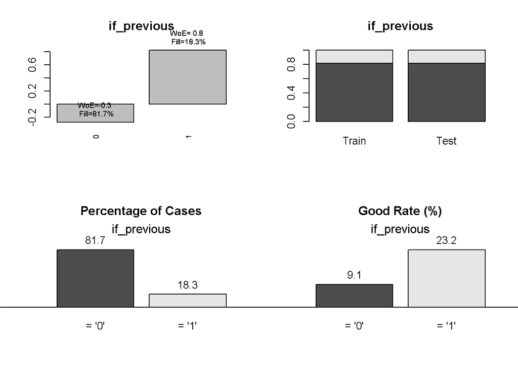

```
## Information Value 0.07
```

```
##      [,1]
## [1,]  0.7
## [2,]  1.9
## [3,]  3.1
## [4,]  4.3
## [5,]  5.5
## [6,]  6.7
## [7,]  7.9
```

```
## [1] 0.7 1.9
```

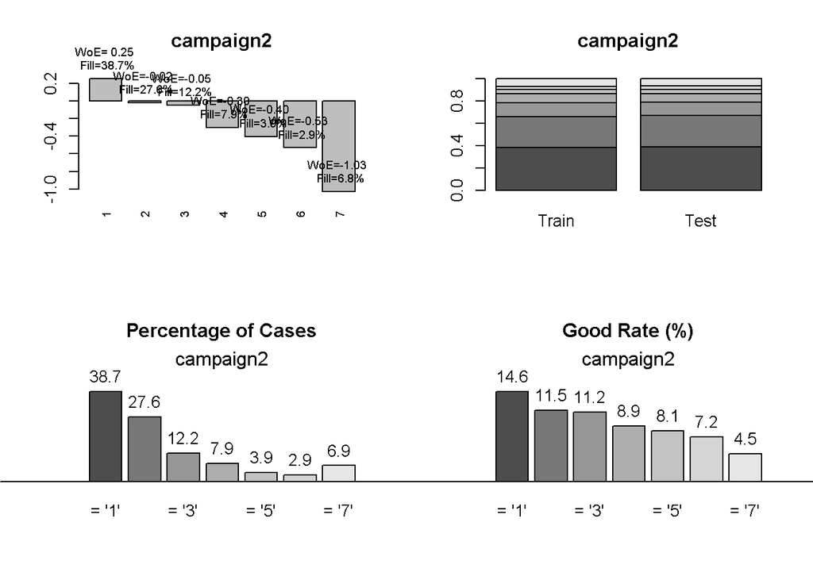

Dla tak przygotowanej bazy, na próbie treningowej, zostały oszacowane modele metodą logit. Wynikiem pierwszej estymacji jest model tylko ze stałą, kolejnej model z uwzględnieniem wszystkich zmiennych, nastęnie model dla zmiennych ze wskaźnikiem Gini powyżej 0.1 oraz model ze zmienną *duration* jako offset.

# Budowa modelu

## Model podstawowy

Do budowy modelu wybrano zmienne, których wspołczynniki Gini przekracza 0.1. Wykorzystując te zmienne oszacowano model, w którym wszytskie zmienne były istotne statystycznie. Pominieto zmienną *duration*, która *apriori* nie jest znana przed zakończeniem połączenia. Podsumowanie modelu jest następujące:

|  | Estimate | Std. Error | z value | Pr(>\|z\|) |
| --- | --- | --- | --- | --- |
| (Intercept) | -2.009 | 0.020 | -99.757 | 0.000 |
| year_woe | 0.639 | 0.022 | 28.428 | 0.000 |
| poutcome_woe | 0.526 | 0.027 | 19.805 | 0.000 |
| contact_woe | 0.326 | 0.044 | 7.491 | 0.000 |
| housing_woe | 0.632 | 0.046 | 13.709 | 0.000 |
| job_woe | 0.123 | 0.054 | 2.265 | 0.024 |
| balance_woe | 0.566 | 0.059 | 9.602 | 0.000 |
| age_woe | 0.352 | 0.052 | 6.774 | 0.000 |
| campaign_woe | 0.494 | 0.069 | 7.172 | 0.000 |
| education_woe | 0.417 | 0.092 | 4.533 | 0.000 |
| marital_woe | 0.429 | 0.092 | 4.662 | 0.000 |

Jednak jako ciekawostkę, mogącą stanowić element motywacyjny dla telefonicznych sprzedawców, przygotowano również model uwzględniający czas trwania połączenia (*duration*), jednak jako zmienną typu *offset*. Takie podejście umożliwiałoby ciągłą w czasie aktualizację wartości szacowanego prawdopodbieństwa sukcesu, które średnio wzrasta wraz z wydłużaniem się rozmowy.

Podsumowanie modelu jest następujące:

|  | Estimate | Std. Error | z value | Pr(>\|z\|) |
| --- | --- | --- | --- | --- |
| (Intercept) | -7.457 | 0.021 | -359.384 | 0.000 |
| year_woe | 0.683 | 0.024 | 28.184 | 0.000 |
| poutcome_woe | 0.512 | 0.028 | 18.291 | 0.000 |
| contact_woe | 0.238 | 0.045 | 5.250 | 0.000 |
| housing_woe | 0.677 | 0.048 | 14.051 | 0.000 |
| job_woe | 0.169 | 0.057 | 2.960 | 0.003 |
| balance_woe | 0.479 | 0.061 | 7.907 | 0.000 |
| age_woe | 0.271 | 0.055 | 4.946 | 0.000 |
| campaign_woe | 0.300 | 0.074 | 4.032 | 0.000 |
| education_woe | 0.496 | 0.096 | 5.158 | 0.000 |
| marital_woe | 0.444 | 0.096 | 4.630 | 0.000 |

## Wykorzystanie xgboost i drzewa decyzyjnego do szukania interakcji

Dla zadanego problemu zastosowano również algorytm xgboost, który jest modelem konkurencyjnym w stosunku do logitowego, a jednocześnie posłuży do szukania interkacji, którymi wzbogacony zostanie podstawowy model zapreznetowany wcześniej. Parametry optymalizowano przy zastosowaniu kroswalidacji w dwóch niezależnych sekwencjach. W pierwszym przetwarzaniu optymalizowano głębokość drzewa *(max_depth)*, liczbę powtórzeń *(nrounds)*, parametr regularyzacji *(gamma)* oraz *learnng rate (eta)*. Dla optymalnych wartości parametrów zoptymalizowano % kolum *(colsample_bytree)*, na podstawie których budowane są kolejne drzewa,% obserwacji drzewa do powstania kolejnego węzła *(min_child_weight)*, % obserwacji zbioru treningowego stosowany do budowy drzew *(subsample)*.

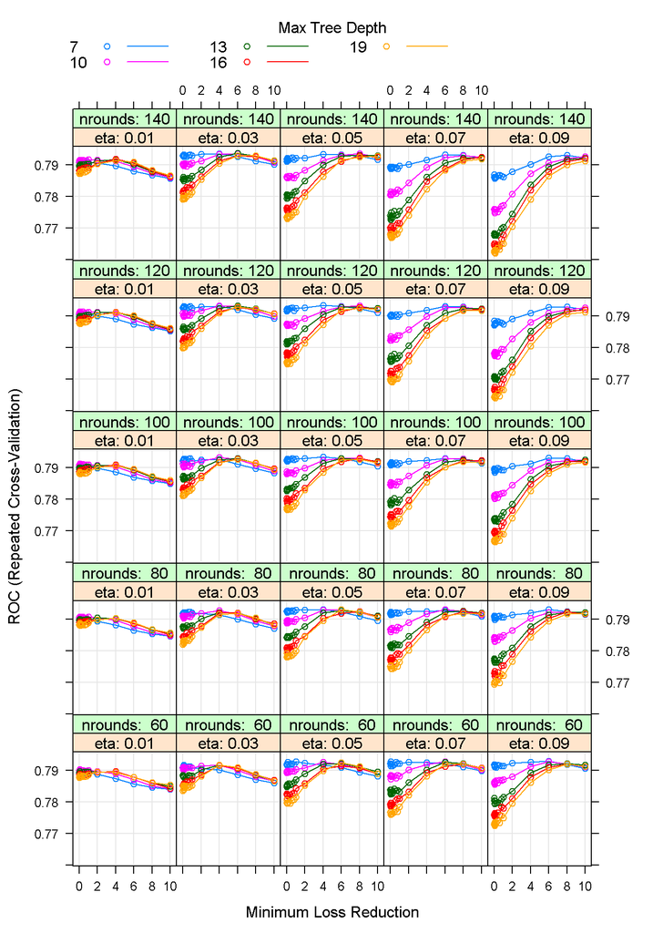

```
##     nrounds max_depth  eta gamma colsample_bytree min_child_weight
## 630     140        13 0.03     6              0.8              0.6
##     subsample
## 630       0.7
```

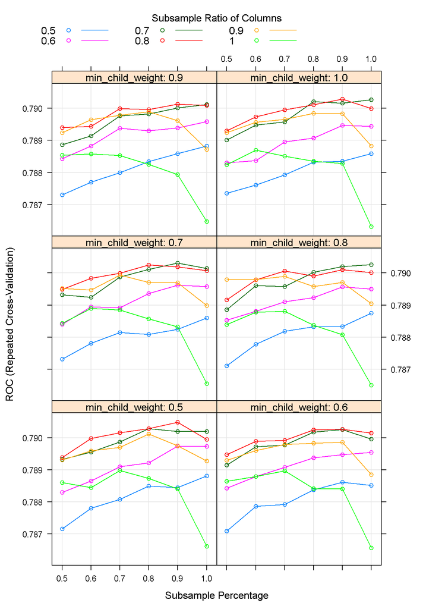

[output not shown]

Współczynnik Gini na xgboost na zbiorze trenignowym wynosi 0.62960157434028, z kolei na testowym 0.560664677400198. Wartości współczynnika dla wybranego modelu logit wynoszą odpowiednio 0.564768143366271 oraz 0.531851165550942. Postanowiono przetestować hipotezę o równym rozkładzie predykcji z modelu logit i xgboost.

```r
#zbiorki do drzewa
xg_train %>% select(-pxg,-y) %>%  filter((xg=="yes" & def==1)|(xg=="no" & def==0))->ok
xg_train %>% select(-pxg,-y) %>%  filter(xg=="no")->nie_ok

set.seed(131)
treeGrid <- expand.grid(maxdepth = 1:15)
treeControlm <- trainControl(method = "repeatedcv",
                             number =5, #fold cross-validacji
                             repeats =5, #liczba powtorzen cv
                             ## Estimate class probabilities
                             classProbs = TRUE,
                             #verboseIter = TRUE,
                             ## Evaluate performance using
                             ## the following function
                             summaryFunction = twoClassSummary,
                             selectionFunction = "best"
)
tree.fitm <- train(xg~.-duration-def,
                   data = ok,
                   method = "rpart2",
                   trControl = treeControlm,
                   #verbose = FALSE,
                   tuneGrid = treeGrid,
                   ## Specify which metric to optimize
                   metric = "ROC")

#str(tree.fitm)
```

AUC określające jakość dopasowania drzewa do predyckji z xgboost:

```
## Area under the curve: 0.9285
```

Zwizualizowanie drzewa będzie pomocne przy szukaniu interakcji:

[figure not shown]

# Diagnostyka modeli

Na podstawie przeprowadzonej analizy otrzymano model postaci:

|  | Estimate | Std. Error | z value | Pr(>\|z\|) |
| --- | --- | --- | --- | --- |
| (Intercept) | -1.947 | 0.024 | -82.168 | 0.000 |
| poutcome_woe | 0.558 | 0.043 | 12.892 | 0.000 |
| job_woe | 0.122 | 0.055 | 2.234 | 0.025 |
| balance_woe | 0.574 | 0.059 | 9.693 | 0.000 |
| age_woe | 0.338 | 0.052 | 6.465 | 0.000 |
| campaign_woe | 0.505 | 0.069 | 7.310 | 0.000 |
| education_woe | 0.410 | 0.092 | 4.447 | 0.000 |
| marital_woe | 0.433 | 0.092 | 4.687 | 0.000 |
| year_woe:if_success0 | 0.643 | 0.023 | 27.851 | 0.000 |
| year_woe:if_success1 | 0.802 | 0.079 | 10.113 | 0.000 |
| contact_woe:if_previous0 | 0.415 | 0.045 | 9.118 | 0.000 |
| contact_woe:if_previous1 | -0.607 | 0.165 | -3.676 | 0.000 |
| housing_woe:pdays2<90 | 0.526 | 0.054 | 9.761 | 0.000 |
| housing_woe:pdays2>=90 | 0.738 | 0.088 | 8.427 | 0.000 |

Dla modelu z offsetem zastosowano ten sam zestaw interakcji:

|  | Estimate | Std. Error | z value | Pr(>\|z\|) |
| --- | --- | --- | --- | --- |
| (Intercept) | -7.347 | 0.025 | -296.784 | 0.000 |
| poutcome_woe | 0.656 | 0.045 | 14.449 | 0.000 |
| job_woe | 0.168 | 0.057 | 2.942 | 0.003 |
| balance_woe | 0.483 | 0.061 | 7.953 | 0.000 |
| age_woe | 0.247 | 0.055 | 4.505 | 0.000 |
| campaign_woe | 0.309 | 0.075 | 4.141 | 0.000 |
| education_woe | 0.489 | 0.096 | 5.073 | 0.000 |
| marital_woe | 0.432 | 0.096 | 4.493 | 0.000 |
| year_woe:if_success0 | 0.719 | 0.025 | 28.777 | 0.000 |
| year_woe:if_success1 | 0.730 | 0.082 | 8.929 | 0.000 |
| contact_woe:if_previous0 | 0.320 | 0.047 | 6.837 | 0.000 |
| contact_woe:if_previous1 | -1.357 | 0.181 | -7.498 | 0.000 |
| housing_woe:pdays2<90 | 0.599 | 0.056 | 10.734 | 0.000 |
| housing_woe:pdays2>=90 | 0.656 | 0.093 | 7.017 | 0.000 |

Dla otrzymango modelu wspłczynniki Gini na próbie treningowej i testowej wynoszą odpowiednio: 0.571 0.54 Podczas gdy dla modelu bez interakcji: 0.565 0.532

Przeprowadzono również test na równość rozkładów krzywych ROC. P-value testu wynosi 0, co wskazuje, że należy odrzucić hipotezę zerową o równych rozkładach krzywych. Podsumowując, dodanie interakcji poprawiło jakość predkcji. Dalsza analiza będzie dotyczyć otrzymanego modelu.

Dla wybranych modeli przeprowadzono testy diagnostyczne

Dla modeli ze zmiennymi wybranymi na podstawie Giniego została przeprowadzona analiza jakości dopasowania. Porównano model z maksymalną liczbą zmiennych z wybranym modelem, jego hipoteza zerowa mówi, że model jest dobrze dopasowany do danych. Dla modeli bez offsetu i z offsetem p-value przyjmuje wartość 1, co oznacza, że modele są tak samo dobre jak model ogólny. Kolejny test to test LR na istotność zmiennych, w którym sprawdza się, czy maksimum funkcji wiarygodności dla wybranego modelu jest większe niż dla modelu tylko ze stałą. W przypadku estymowanych modelu odrzucamy hipotezę, że zmienne są łącznie nieistotne. Podstawowym testem na jakość dopasowania w modelach dla binarnej zmiennej zależnej jest test Hosmera - Lemeshowa. Jego hipoteza zerowa mówi, że model jest dobrze dopasowany do danych, ma on jednak wiele wad, przede wszystkim jest bardzo wrażliwy na liczbę przedziałów. Niestety, w przypadku wybranych modeli należy odrzucić hipotezę zerową, że model ma poprawną formę funkcyjną, może to jednak wynikać z licznych wad testu.

| nazwa testu | model | model_offset |
| --- | --- | --- |
| Chi2 | 1 | 1 |
| LR | 0 | 0 |
| Hosmer-Lemeshow | 0 | 0 |
| roc(model vs baza) | 0 |  |
| roc(model vs max) | 0.005 |  |
| roc(offset vs model) |  | 0 |

Pozostałe testy diagnostyczne dla modelu *model*:

```
##        chiSq    df       pVal
## PrI  32629.5 31632 0.00004288 ***
## drI  18595.9 31632          1
## PrG  13816.2 12486         NA
## drG   9843.3 12486          1
## PrCT 13816.2 12486         NA
## drCT  9843.3 12486          1
## ---
## Signif. codes:  0 '***' 0.001 '**' 0.01 '*' 0.05 '.' 0.1 ' ' 1
##                        val df                  pVal
## HL chiSq         83.807346 10 0.0000000000000896791 ***
## mHL F            15.258473 11                    NA
## OsRo Z            5.283091 NA 0.0000001270219266963 ***
## SstPgeq0.5 Z      8.234410 NA                    NA
## SstPl0.5 Z        0.198756 NA              0.842454
## SstBoth chiSq    67.845014  2 0.0000000000000018520 ***
## SllPgeq0.5 chiSq 61.762956  1 0.0000000000000038739 ***
## SllPl0.5 chiSq    0.039513  1              0.842437
## SllBoth chiSq    66.397391  2 0.0000000000000038194 ***
## ---
## Signif. codes:  0 '***' 0.001 '**' 0.01 '*' 0.05 '.' 0.1 ' ' 1
```

Niestety przedstawione testy wskazują na niepoprawną formę funkcyjną, jednak test Skutela dla dodatkowego wektora *z1* nie daje podstaw do odrzuceia hipotezy o poprawnym dopasowaniu do danych.

Pozostałe testy diagnostyczne dla modelu *model_offset*:

```
##      chiSq    df pVal
## PrI  18124 31632    1
## drI  14858 31632    1
## PrG  18034 31327    1
## drG  14817 31327    1
## PrCT 18034 31327    1
## drCT 14817 31327    1
##                        val df      pVal
## HL chiSq          555.0900 10        NA
## mHL F             113.9975 11        NA
## OsRo Z                  NA NA        NA
## SstPgeq0.5 Z        2.5836 NA 0.0097776 **
## SstPl0.5 Z         27.9429 NA        NA
## SstBoth chiSq     787.4812  2        NA
## SllPgeq0.5 chiSq    6.0971  1 0.0135405 *
## SllPl0.5 chiSq   1171.6539  1        NA
## SllBoth chiSq    1172.5662  2        NA
## ---
## Signif. codes:  0 '***' 0.001 '**' 0.01 '*' 0.05 '.' 0.1 ' ' 1
```

Następnie zostały wyznaczone wartości Giniego dla modelu z maksymalną liczbą zmiennych, bez offsetu i z offsetem na próbie treningowej i testowej. Widać wyraźną poprawę po oszacowaniu modelu z użyciem zmiennej duration jako offset. Gini dla wybranych zmiennych jest również wyższy od modelu ogólnego.

Test PSI sprawdza, na ile dwa rozkłady się od siebie różnią. Chcemy, aby jego wartości były jak najmniejsze, znowu widać poprawę w modelu z offsetem.

| statystyka | model | model_offset |
| --- | --- | --- |
| Gini train | 0.571 | 0.818 |
| Gini test | 0.54 | 0.808 |
| KS train | 0.457 | 0.666 |
| KS test | 0.443 | 0.663 |
| PSI | 0.003 | 0.002 |

Dalsza analiza dotyczyć będzie modelu logit wzbogaconego o interkacje zwanego dalej *modele**. W tabelach poniżej można zaobserwować, czy jakiś score pojawia się często, co może świadczyć o tym, że małe zmiany generują ryzyko zmiany oceny jakości modelu.

Zbiór treningowy:

```
##               Var1        Freq
## 1 286.284457178996 0.002875561
## 2 201.924222388889 0.002591165
## 3 192.556077867668 0.002527966
```

Zbiór testowy:

```
##               Var1        Freq
## 1 192.556077867668 0.003170624
## 2 201.924222388889 0.002654476
## 3 286.284457178996 0.002580740
```

Rozkład nie kumuluje się w w poszczególnych wartościach.

Analizę dopasowania i stabilności modelu przeprowadzono również na wybranym segemncie.Wartości statystyk dla segmentu, w którym znajdują się lepsi klienci,czyli Ci z którymi kontaktowano się już wcześniej:

| statystyka | model |
| --- | --- |
| Gini train | 0.652 |
| Gini test | 0.684 |
| KS train | 0.54 |
| KS test | 0.569 |
| PSI | 0.008 |

Przedstawione statystyki wskazują, że dopasowanie na zbiorze testowym jest lepsze niż na treningowym. Spowodowane to może być niezbilansowaniem próby.

## Wykorzystanie algorytmu selekcji zmiennych

Podsumowanie modelu z algorytmu *stepwise*:

|  | Estimate | Std. Error | z value | Pr(>\|z\|) |
| --- | --- | --- | --- | --- |
| (Intercept) | -2.008 | 0.020 | -99.596 | 0 |
| year_woe | 0.637 | 0.022 | 28.317 | 0 |
| poutcome_woe | 0.526 | 0.027 | 19.766 | 0 |
| housing_woe | 0.634 | 0.045 | 13.966 | 0 |
| balance_woe | 0.548 | 0.059 | 9.215 | 0 |
| age_woe | 0.389 | 0.049 | 7.958 | 0 |
| contact_woe | 0.339 | 0.044 | 7.775 | 0 |
| campaign_woe | 0.479 | 0.069 | 6.949 | 0 |
| education_woe | 0.453 | 0.090 | 5.064 | 0 |
| week_day_woe | 1.042 | 0.199 | 5.245 | 0 |
| marital_woe | 0.433 | 0.092 | 4.706 | 0 |
| loan_woe | 0.340 | 0.093 | 3.655 | 0 |

Podsumowanie modelu z algorytmu *forward*:

|  | Estimate | Std. Error | z value | Pr(>\|z\|) |
| --- | --- | --- | --- | --- |
| (Intercept) | -2.008 | 0.020 | -99.596 | 0 |
| year_woe | 0.637 | 0.022 | 28.317 | 0 |
| poutcome_woe | 0.526 | 0.027 | 19.766 | 0 |
| housing_woe | 0.634 | 0.045 | 13.966 | 0 |
| balance_woe | 0.548 | 0.059 | 9.215 | 0 |
| age_woe | 0.389 | 0.049 | 7.958 | 0 |
| contact_woe | 0.339 | 0.044 | 7.775 | 0 |
| campaign_woe | 0.479 | 0.069 | 6.949 | 0 |
| education_woe | 0.453 | 0.090 | 5.064 | 0 |
| week_day_woe | 1.042 | 0.199 | 5.245 | 0 |
| marital_woe | 0.433 | 0.092 | 4.706 | 0 |
| loan_woe | 0.340 | 0.093 | 3.655 | 0 |

Podsumowanie modelu z algorytmu *backward*:

|  | Estimate | Std. Error | z value | Pr(>\|z\|) |
| --- | --- | --- | --- | --- |
| (Intercept) | -2.008 | 0.020 | -99.596 | 0 |
| year_woe | 0.637 | 0.022 | 28.317 | 0 |
| poutcome_woe | 0.526 | 0.027 | 19.766 | 0 |
| contact_woe | 0.339 | 0.044 | 7.775 | 0 |
| housing_woe | 0.634 | 0.045 | 13.966 | 0 |
| balance_woe | 0.548 | 0.059 | 9.215 | 0 |
| age_woe | 0.389 | 0.049 | 7.958 | 0 |
| campaign_woe | 0.479 | 0.069 | 6.949 | 0 |
| education_woe | 0.453 | 0.090 | 5.064 | 0 |
| marital_woe | 0.433 | 0.092 | 4.706 | 0 |
| loan_woe | 0.340 | 0.093 | 3.655 | 0 |
| week_day_woe | 1.042 | 0.199 | 5.245 | 0 |

W przypadku wszytskich trzech algotymów ostateczny model jest tej samej postaci. Diagnostyce i porównaniu z modelami *baza* i *max* poddany będzie model *stepwise*.

Zmienne do modelu możemy też wybrać algorytmem selekcji zmiennych. Ponadto, jego wyniki stanowią analizę jakości dyskryminacyjnej zmiennych - im częściej zmienna wybierana jest do modelu (wiecej czarnych pól) tym większa siła. W ninijszym badaniu największą siłą dyskryminacyjna charakteryzują się zmienne: *year_woe*,*poutcome_woe* i *hausing_woe*. Z kolei najmniejszą: *contact_woe*, *loan_woe* i *marital_woe*.

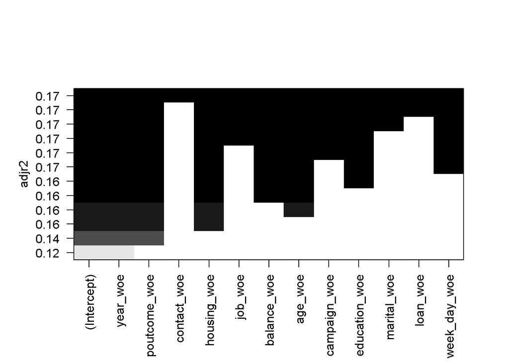

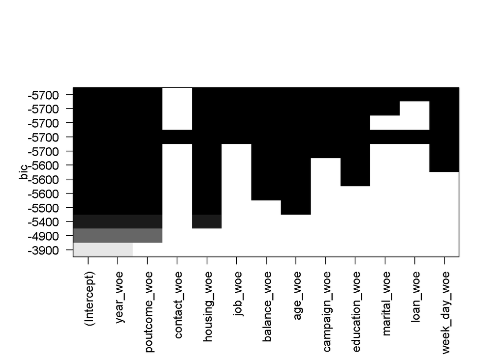

Dla modelu otrzymanego metodą *stepwise* przedstawiono statystyki i miary jakości dopasowania. Miary dopasowania są niższe niż w *modelu*, ponieważ nie uwzględnia jednej zmiennej(przez dość wysoki parametr k) oraz interakcji. Zauważalny jest spadek dopasowania na zbiorze testowym (Gnini spadł o około 1.3%).

| nazwa testu/statystyki | model |
| --- | --- |
| Chi2 | 1 |
| LR | 0 |
| Hosmer-Lemeshow | 0 |
| roc(model vs baza) | 0 |
| roc(model vs max) | 0.005 |
| Gini train | 0.567 |
| Gini test | 0.533 |
| KS train | 0.451 |
| KS test | 0.435 |
| PSI | 0.003 |

Jednak jedynie w przypadku testu Skutela dla dodatkowego wektora *z1* nie ma podstaw do odrzucenia hipotezy zerowej o poprawnym dopasowaniu do danych.

```
##        chiSq    df       pVal
## PrI  32629.5 31632 0.00004288 ***
## drI  18595.9 31632          1
## PrG  13816.2 12486         NA
## drG   9843.3 12486          1
## PrCT 13816.2 12486         NA
## drCT  9843.3 12486          1
## ---
## Signif. codes:  0 '***' 0.001 '**' 0.01 '*' 0.05 '.' 0.1 ' ' 1
##                        val df                  pVal
## HL chiSq         83.807346 10 0.0000000000000896791 ***
## mHL F            15.258473 11                    NA
## OsRo Z            5.283091 NA 0.0000001270219266963 ***
## SstPgeq0.5 Z      8.234410 NA                    NA
## SstPl0.5 Z        0.198756 NA              0.842454
## SstBoth chiSq    67.845014  2 0.0000000000000018520 ***
## SllPgeq0.5 chiSq 61.762956  1 0.0000000000000038739 ***
## SllPl0.5 chiSq    0.039513  1              0.842437
## SllBoth chiSq    66.397391  2 0.0000000000000038194 ***
## ---
## Signif. codes:  0 '***' 0.001 '**' 0.01 '*' 0.05 '.' 0.1 ' ' 1
```

Po porównaniu wszystkich szacowanych modeli i testów jakości dopasowania dla nich, do utworzenia karty scoringowej został wybrany model ze zmiennymi: stała, *job_woe*, *age_woe*, *education_woe*, *poutcome_woe*, *balance_woe*, *campaign_woe*, *marital_woe* oraz interakcji między *year_woe* a indykatorem sukcesu w poprzednim kontakcie, *contact_woe* a indykatorem wcześniejszej próby kontaktu i *housing_woe* a indykatorem liczby dni od poprzedniego kontaktu(+/-90 dni).

# Przygotowanie karty scoringowej

Poniżej widać histogramy rozkładu dobrych i złych klientów

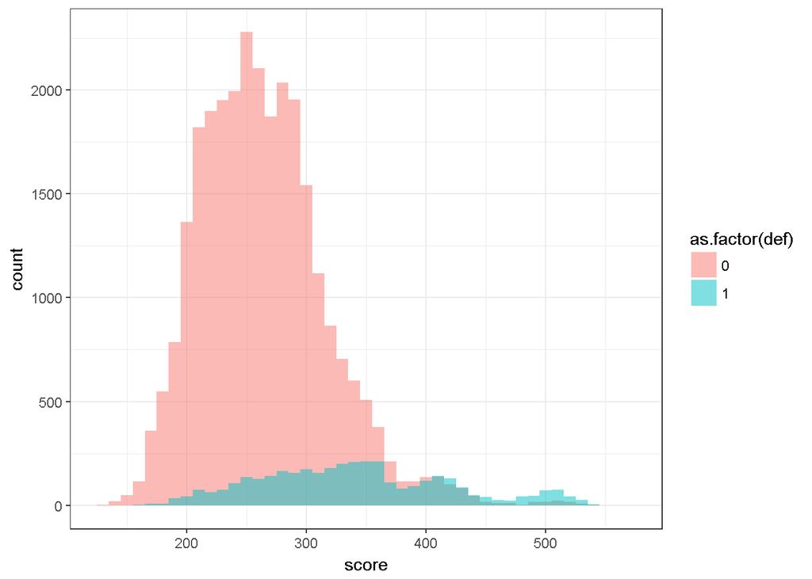

Na podstawie przeprowadzonej analizy możliwe jest przygotowanie karty scoringowej. Zastosowanie interakcji zmiennych *woe* ze zmienymi binarnymi nie wymaga szacowania oddzielnych miar dla interkacji, ponieważ ich wpływ zostanie uwzględniony w predykcji prawdopodbieństwa. Otrzymana karta przyjmuje następującą postać:

```r
kh(karta)
```

| Zmienna_org | Zmienna_c | Zmienna | Groups | WoE | Parametr | points |
| --- | --- | --- | --- | --- | --- | --- |
| NA | NA | (Intercept) | NA | NA | -1.9467004 | 525.5428 |
| age | age_coarse | age_woe | <= 58 | -0.2817 | 0.3381186 | -5.4966 |
| age | age_coarse | age_woe | <= 37 | -0.0565 | 0.3381186 | -1.1024 |
| age | age_coarse | age_woe | <= 28 | 0.5518 | 0.3381186 | 10.7668 |
| age | age_coarse | age_woe | <= Inf | 1.0145 | 0.3381186 | 19.7950 |
| balance | balance_coarse | balance_woe | <= 919 | -0.0409 | 0.5740131 | -1.3548 |
| balance | balance_coarse | balance_woe | <= 93 | -0.4317 | 0.5740131 | -14.3001 |
| balance | balance_coarse | balance_woe | <= Inf | 0.3465 | 0.5740131 | 11.4778 |
| balance | balance_coarse | balance_woe | <= -55 | -0.9920 | 0.5740131 | -32.8600 |
| campaign | campaign_coarse | campaign_woe | <= 3 | -0.0306 | 0.5052320 | -0.8922 |
| campaign | campaign_coarse | campaign_woe | <= Inf | -1.0293 | 0.5052320 | -30.0101 |
| campaign | campaign_coarse | campaign_woe | <= 1 | 0.2514 | 0.5052320 | 7.3298 |
| campaign | campaign_coarse | campaign_woe | <= 6 | -0.3715 | 0.5052320 | -10.8314 |
| NA | NA | contact_woe:if_previous0 | NA | NA | 0.4145234 | NA |
| NA | NA | contact_woe:if_previous1 | NA | NA | -0.6074247 | NA |
| education | education | education_woe | primary | -0.3260 | 0.4100535 | -7.7142 |
| education | education | education_woe | secondary | -0.1158 | 0.4100535 | -2.7402 |
| education | education | education_woe | unknown | 0.1656 | 0.4100535 | 3.9186 |
| education | education | education_woe | tertiary | 0.2840 | 0.4100535 | 6.7204 |
| NA | NA | housing_woe:pdays2<90 | NA | NA | 0.5256250 | NA |
| NA | NA | housing_woe:pdays2>=90 | NA | NA | 0.7383933 | NA |
| job | job | job_woe | management | 0.1858 | 0.1219124 | 1.3072 |
| job | job | job_woe | blue-collar | -0.5234 | 0.1219124 | -3.6823 |
| job | job | job_woe | technician | -0.0637 | 0.1219124 | -0.4481 |
| job | job | job_woe | entrepreneur | -0.3853 | 0.1219124 | -2.7107 |
| job | job | job_woe | self-employed & unknown | 0.0152 | 0.1219124 | 0.1069 |
| job | job | job_woe | student | 1.1090 | 0.1219124 | 7.8021 |
| job | job | job_woe | unemployed | 0.3221 | 0.1219124 | 2.2661 |
| job | job | job_woe | housmaid & services | -0.3084 | 0.1219124 | -2.1697 |
| job | job | job_woe | admin. | 0.0483 | 0.1219124 | 0.3398 |
| job | job | job_woe | retired | 0.8000 | 0.1219124 | 5.6282 |
| marital | marital | marital_woe | married | -0.1656 | 0.4325581 | -4.1337 |
| marital | marital | marital_woe | divorced | -0.0066 | 0.4325581 | -0.1647 |
| marital | marital | marital_woe | single | 0.2983 | 0.4325581 | 7.4462 |
| poutcome | poutcome | poutcome_woe | unknown | -0.2757 | 0.5575977 | -8.8714 |
| poutcome | poutcome | poutcome_woe | success | 2.5881 | 0.5575977 | 83.2792 |
| poutcome | poutcome | poutcome_woe | failure | 0.1111 | 0.5575977 | 3.5749 |
| poutcome | poutcome | poutcome_woe | other | 0.4581 | 0.5575977 | 14.7406 |
| NA | NA | year_woe:if_success0 | NA | NA | 0.6433523 | NA |
| NA | NA | year_woe:if_success1 | NA | NA | 0.8024677 | NA |

## Rating

Na podstawie skalibrowanego rozkładu prawdopodobieństwa, zaproponowano klasy ratingowe. Poniżej zaprezentowano emipryczne prawdopodbieństwo udanej sprzedaży w klasach. Podział na klasy stanowi segmentację klientów, która może być użyteczna przy wyznaczaniu grup docelowych klientów.

```r
br(prop.table(table(train$GR_RYZ,train$def),1))
```

```
##
##         0     1
##   A 0.471 0.529
##   B 0.707 0.293
##   C 0.846 0.154
##   D 0.909 0.091
##   E 0.938 0.062
##   F 0.965 0.035
```

Monotoniczny charakter ratingu potwierdza, że zastosowana metodologia może być zastosowana w celach segmentacji klientów oraz selekcji profili z największym prawdopodbieństwem sukcesu.

## Optymalny punkt odcięcia

Ostatnim etapem analizy jest dobranie optymalnego punktu odcięcia. Przy założeniu, że cost ratio przyjmuje następującą postać: (FP-TN)/(FN-TP)=(-10-0)/(-50-10), otrzymane punkty odcięcia scoru są następujące:

| nazwa | wartosc dla cp1 |
| --- | --- |
| Youden | 311.08 |
| MaxSpSe | 288.923 |
| SpEqualSe | 288.923 |
| ROC01 | 295.7 |
| MaxEfficiency | 408.55 |
| MinPvalue | 133.446 |
| CB | 572.756 |

Sprawdzenie: Zakładając, że jako optymalny punkt odcięcia został wybrany na podstawie algorytmu Youdena to srednie prawdopodbieństwo empiryczne na próbie treningowej klientów o scorze wyższym niż zakładany wynosi 0.3364 i dotyczy 0.2154 populacji.

# Podsumowanie